# Resolución Actividad 2 máster Bioinformática UNIR (2024)

Resolución Actividad 2 máster Bioinformática UNIR (2024) Elena Díez García 2024-05-13

## Preparación del script

Preparación del **entorno de trabajo** mediante la importación del dataframe **estudio1**, la instalación de los paquetes y librerías necesarias. Creamos también el dataframe **estudio1Res** donde metemos las categorías para Sexo e IMC.

```r
estudio1<-read.csv("/Users/emmettdiez/Desktop/estudio1.csv", na.strings = "", fileEncoding = "UTF-8-BOM")

estudio1$categorias<-cut(estudio1$IMC, breaks = c(-Inf, 30, Inf), labels = c("bajo", "alto"))
estudio1$categoria_final<- with(estudio1,ifelse(sexo==1 & categorias=="bajo", 1,
                                                ifelse(sexo==1 & categorias=="alto", 2,
                                                       ifelse(sexo==2 & categorias=="bajo", 3, 4))))
estudio1$categoriasdos<-with(estudio1, ifelse (sexo==1, "hombre", "mujer"))


estudio1Res <- estudio1%>%
  select(categorias, categoria_final, IMC, sexo, alimento1:alimento20, nutriente1:nutriente19)
```

## Ejercicio 1

En primer lugar, con el test de Levene comprobamos la **homogeneidad** **de las varianzas** para ver si son iguales entre los distintos grupos y ver el grado de dispersión. Para los p-valores <0.05 no existen diferencias significativas (hay homogeneidad) y para los p-valores >0.05 existirán diferencias.

```r
with (estudio1Res, leveneTest(alimento1, sexo))
with (estudio1Res, leveneTest(alimento2, sexo))
with (estudio1Res, leveneTest(alimento3, sexo))
with (estudio1Res, leveneTest(alimento4, sexo))
with (estudio1Res, leveneTest(alimento5, sexo))
with (estudio1Res, leveneTest(alimento6, sexo))
with (estudio1Res, leveneTest(alimento7, sexo))
with (estudio1Res, leveneTest(alimento8, sexo))
with (estudio1Res, leveneTest(alimento9, sexo))
with (estudio1Res, leveneTest(alimento10, sexo))
with (estudio1Res, leveneTest(alimento11, sexo))
with (estudio1Res, leveneTest(alimento12, sexo))
with (estudio1Res, leveneTest(alimento13, sexo))
with (estudio1Res, leveneTest(alimento14, sexo))
with (estudio1Res, leveneTest(alimento15, sexo))
with (estudio1Res, leveneTest(alimento16, sexo))
with (estudio1Res, leveneTest(alimento17, sexo))
with (estudio1Res, leveneTest(alimento18, sexo))
with (estudio1Res, leveneTest(alimento19, sexo))
with (estudio1Res, leveneTest(alimento20, sexo))

with (estudio1Res, leveneTest(nutriente1, sexo))
with (estudio1Res, leveneTest(nutriente2, sexo))
with (estudio1Res, leveneTest(nutriente3, sexo))
with (estudio1Res, leveneTest(nutriente4, sexo))
with (estudio1Res, leveneTest(nutriente5, sexo))
with (estudio1Res, leveneTest(nutriente6, sexo))
with (estudio1Res, leveneTest(nutriente7, sexo))
with (estudio1Res, leveneTest(nutriente8, sexo))
with (estudio1Res, leveneTest(nutriente9, sexo))
with (estudio1Res, leveneTest(nutriente10, sexo))
with (estudio1Res, leveneTest(nutriente11, sexo))
with (estudio1Res, leveneTest(nutriente12, sexo))
with (estudio1Res, leveneTest(nutriente13, sexo))
with (estudio1Res, leveneTest(nutriente14, sexo))
with (estudio1Res, leveneTest(nutriente15, sexo))
with (estudio1Res, leveneTest(nutriente16, sexo))
with (estudio1Res, leveneTest(nutriente17, sexo))
with (estudio1Res, leveneTest(nutriente18, sexo))
with (estudio1Res, leveneTest(nutriente19, sexo))
```

A continuación, comprobamos la **normalidad** de los alimentos y nutrientes disponibles y realizamos una interpretación de los resultados obtenidos.

Puesto que nuestra N es de 10.000 observaciones, no podremos realizar el test de Shapiro-Wilk que acepta una N máxima de 5.000 observaciones. Realizaremos el **test de Anderson Darling**.

Planteamos las hipótesis nula y alternativa:

- **H0**: Los datos siguen una distribución normal. Se cumple si p-valor > 0.001.
- **H1**: Los datos no siguen una distribución normal. Se cumple si p-valor < 0.001.

```r
library(nortest)
ad.test(estudio1$alimento1)
ad.test(estudio1$alimento2)
ad.test(estudio1$alimento3)
ad.test(estudio1$alimento4)
ad.test(estudio1$alimento5)
ad.test(estudio1$alimento6)
ad.test(estudio1$alimento7)
ad.test(estudio1$alimento8)
ad.test(estudio1$alimento9)
ad.test(estudio1$alimento10)
ad.test(estudio1$alimento11)
ad.test(estudio1$alimento12)
ad.test(estudio1$alimento13)
ad.test(estudio1$alimento14)
ad.test(estudio1$alimento15)
ad.test(estudio1$alimento16)
ad.test(estudio1$alimento17)
ad.test(estudio1$alimento18)
ad.test(estudio1$alimento19)
ad.test(estudio1$alimento20)
```

```r
library(nortest)
ad.test(estudio1$nutriente1)
ad.test(estudio1$nutriente2)
ad.test(estudio1$nutriente3)
ad.test(estudio1$nutriente4)
ad.test(estudio1$nutriente5)
ad.test(estudio1$nutriente6)
ad.test(estudio1$nutriente7)
ad.test(estudio1$nutriente8)
ad.test(estudio1$nutriente9)
ad.test(estudio1$nutriente10)
ad.test(estudio1$nutriente11)
ad.test(estudio1$nutriente12)
ad.test(estudio1$nutriente13)
ad.test(estudio1$nutriente14)
ad.test(estudio1$nutriente15)
ad.test(estudio1$nutriente16)
ad.test(estudio1$nutriente17)
ad.test(estudio1$nutriente18)
ad.test(estudio1$nutriente19)
```

Como refuerzo, comprobamos gráficamente que las variables no siguen una distribución **normal** mediante **histogramas**. Representamos algunos ejemplos escogidos al azar:

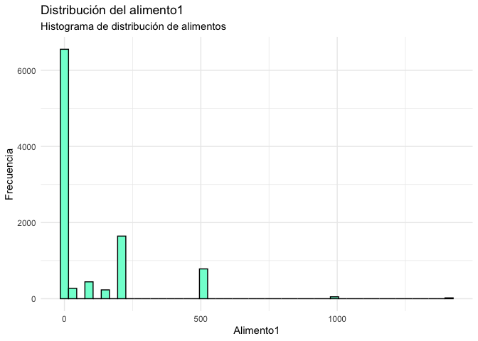

```r
library(ggplot2)
ggplot(estudio1Res, aes(x=alimento1)) +
  geom_histogram(fill="aquamarine", color="black", binwidth=30) +
  labs(title= "Distribución del alimento1",
       subtitle="Histograma de distribución de alimentos",
       x="Alimento1",
       y="Frecuencia") +
  theme_minimal()
```

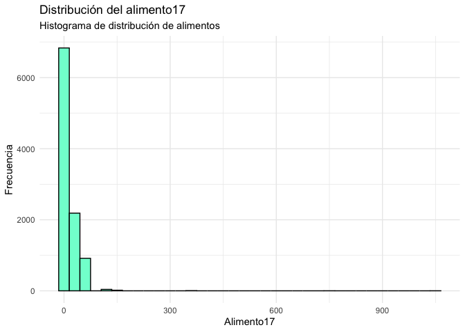

```r
ggplot(estudio1Res, aes(x=alimento17)) +
  geom_histogram(fill="aquamarine", color="black", binwidth=30) +
  labs(title= "Distribución del alimento17",
       subtitle="Histograma de distribución de alimentos",
       x="Alimento17",
       y="Frecuencia") +
  theme_minimal()
```

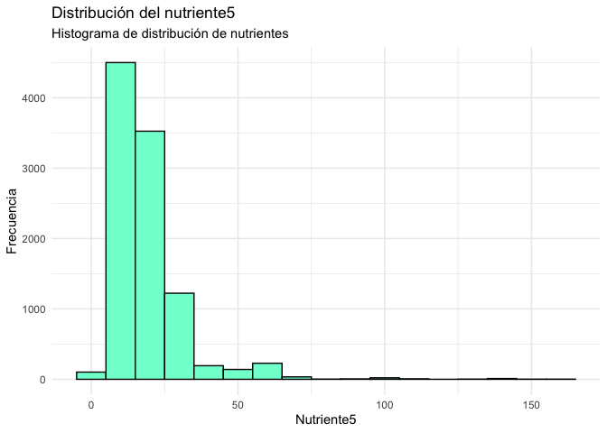

```r
ggplot(estudio1Res, aes(x=nutriente5)) +
  geom_histogram(fill="aquamarine", color="black", binwidth=10) +
  labs(title= "Distribución del nutriente5",
       subtitle="Histograma de distribución de nutrientes",
       x="Nutriente5",
       y="Frecuencia") +
  theme_minimal()
```

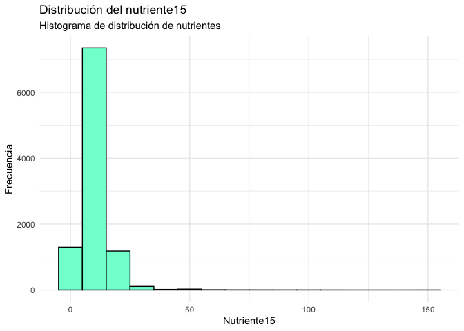

```r
ggplot(estudio1Res, aes(x=nutriente15)) +
  geom_histogram(fill="aquamarine", color="black", binwidth=10) +
  labs(title= "Distribución del nutriente15",
       subtitle="Histograma de distribución de nutrientes",
       x="Nutriente15",
       y="Frecuencia") +
  theme_minimal()
```

Si analizamos la **curtosis** de las distribuciones mostradas en los histogramas, podemos observar que todos presentan **leptocurtosis**, ya que los datos se concentran de forma puntiaguda y elevada en la parte izquierda de la gráfica.

## Ejercicio 2

Calcular y analizar **estadísticas descriptivas** de los valores sin transformar. En nuestro caso, los valores son **no paramétricos** puesto que no siguen distribución normal, por lo que calcularemos:

- **Mediana**
- **IQR - Rango intercuartílico**

Para ello utilizamos la **división** realizada al principio del script con los datos por **Sexo** e **IMC** donde:

- **Categoría 1**: sexo 1, IMC <=30
- **Categoría 2**: sexo 1, IMC >30
- **Categoría 3**: sexo 2, IMC <=30
- **Categoría 4**: sexo 2, IMC >30

Con la función **select**, hacemos un dataframe resumido con las categorías, nutrientes y alimentos que necesitamos para simplificar el trabajo.

```r
estudio1Res <- estudio1 %>%
  select(categorias, categoria_final, IMC, sexo, alimento1:alimento20, nutriente1:nutriente19)
```

Obtencion de la **mediana** para **alimentos** y **nutrientes**. Se muestra el comando summary y una también la síntesis con **apply**.

```r
summary(estudio1Res$alimento1)
summary(estudio1Res$nutriente1)

apply(estudio1Res[, 5:24], 2, median)
apply(estudio1Res[, 25:43], 2, median)
```

Muchos alimentos presentan una **mediana** **= 0**, es decir, muchos de ellos no son ingeridos por la mitad de la población.

Calculamos **IQR** para **alimentos** y **nutrientes**, mostrando el comando desglosado y el condensado.

```r
quantile(estudio1Res$alimento1, probs= c(0, 0.25, 0.75, 1))
quantile(estudio1Res$nutriente1, probs= c(0, 0.25, 0.75, 1))

apply(estudio1Res[, 5:24], 2, quantile, probs=c(0, 0.25, 0.75, 1))
apply(estudio1Res[, 25:43], 2, quantile, probs=c(0, 0.25, 0.75, 1))
```

El **IQR** nos muestra los valores de los percentiles, desde el mínimo hasta el máximo, quedando entre medias el Q1 (p25), el Q2 (p50) o mediana y el Q3 (p75).

## Ejercicio 3

Aplicar e interpretar el **contraste de hipótesis** de cada uno de los alimentos y nutrientes seleccionados para ver si hay diferencias entre **categorías** de **IMC** en función del **sexo**.

- **H0**: Para cada alimento, existen diferencias entre las categorías creadas con respecto al IMC y el Sexo. Se acepta si p-valor <0.05.
- **H1**: Para cada alimento, no existen diferencias entre las categorías creadas con respecto al IMC y el Sexo. Se acepta si p-valor >0.05.

#### TABLA RESUMEN

Tabla con los resultados de la **mediana**, el **IQR** y p-valor del **t.test.**

```r
select_gtsummary <- estudio1Res %>% select(c("categorias", "sexo", "alimento1", "alimento2", "alimento3", "alimento4", "alimento5", "alimento6", "alimento7", "alimento8", "alimento9", "alimento10", "alimento11", "alimento12", "alimento13", "alimento14", "alimento15", "alimento16", "alimento17", "alimento18", "alimento19", "alimento20",
                                     "nutriente1", "nutriente2", "nutriente3", "nutriente4", "nutriente5", "nutriente6", "nutriente7", "nutriente8", "nutriente9", "nutriente10", "nutriente11", "nutriente12", "nutriente13", "nutriente14", "nutriente15", "nutriente16", "nutriente17", "nutriente18", "nutriente19"))

tabla <- select_gtsummary %>%
  tbl_strata(strata=sexo,
             .tbl_fun = ~.x %>%
               tbl_summary(by=categorias,
                           type=starts_with("alimento")~"continuous",
                           statistic = all_continuous() ~ "{median} ({p25}-{p75})") %>%
               add_p(test = list(all_continuous() ~ "t.test"),
                     pvalue_fun = ~ style_pvalue(.x, digits = 3)))

tabla
```

| **Characteristic** | **1** **bajo**, N = 3,569<sup>1</sup> | **1** **alto**, N = 359<sup>1</sup> | **1** **p-value**<sup>2</sup> | **2** **bajo**, N = 5,923<sup>1</sup> | **2** **alto**, N = 149<sup>1</sup> | **2** **p-value**<sup>2</sup> |
| --- | --- | --- | --- | --- | --- | --- |
| alimento1 | 0 (0-200) | 0 (0-86) | <0.001 | 0 (0-86) | 0 (0-13) | 0.014 |
| alimento2 | 0 (0-157) | 0 (0-157) | 0.879 | 0 (0-200) | 0 (0-157) | 0.024 |
| alimento3 | 0 (0-13) | 0 (0-121) | 0.044 | 0 (0-200) | 0 (0-200) | 0.384 |
| alimento4 | 0.00 (0.00-0.00) | 0.00 (0.00-0.00) | 0.949 | 0.00 (0.00-0.00) | 0.00 (0.00-0.00) | <0.001 |
| alimento5 | 0.00 (0.00-0.00) | 0.00 (0.00-0.00) | <0.001 | 0.0 (0.0-6.7) | 0.0 (0.0-0.0) | 0.002 |
| alimento6 | 0 (0-0) | 0 (0-0) | 0.810 | 0 (0-0) | 0 (0-0) | 0.907 |
| alimento7 | 18 (0-54) | 8 (0-54) | 0.006 | 18 (0-54) | 8 (0-54) | 0.162 |
| alimento8 | 0 (0-18) | 0 (0-54) | <0.001 | 8 (0-54) | 18 (0-98) | 0.164 |
| alimento9 | 0.00 (0.00-0.00) | 0.00 (0.00-0.00) | 0.139 | 0.00 (0.00-0.00) | 0.00 (0.00-0.00) | 0.381 |
| alimento10 | 0.0 (0.0-6.7) | 0.0 (0.0-6.7) | 0.064 | 0.0 (0.0-6.7) | 0.0 (0.0-6.7) | 0.056 |
| alimento11 | 0.0 (0.0-2.0) | 0.0 (0.0-2.0) | 0.093 | 0 (0-4) | 0 (0-2) | 0.785 |
| alimento12 | 21 (3-21) | 7 (3-21) | 0.744 | 21 (3-21) | 7 (3-21) | 0.847 |
| alimento13 | 3 (0-7) | 3 (0-7) | 0.065 | 3 (0-21) | 7 (3-21) | 0.076 |
| alimento14 | 13 (0-13) | 0 (0-13) | 0.007 | 0 (0-13) | 0 (0-13) | 0.447 |
| alimento15 | 7 (0-14) | 7 (0-14) | 0.401 | 7 (0-14) | 7 (0-14) | 0.286 |
| alimento16 | 26 (9-26) | 26 (9-26) | 0.050 | 26 (9-26) | 26 (9-26) | 0.235 |
| alimento17 | 10 (0-21) | 10 (0-21) | 0.035 | 0 (0-21) | 0 (0-21) | 0.113 |
| alimento18 | 21 (0-21) | 21 (0-64) | 0.588 | 21 (10-64) | 21 (10-64) | 0.161 |
| alimento19 | 64 (21-64) | 64 (21-64) | 0.268 | 21 (21-64) | 21 (10-64) | 0.154 |
| alimento20 | 21 (10-64) | 21 (10-64) | 0.492 | 21 (10-21) | 21 (10-21) | 0.628 |
| nutriente1 | 1,138 (872-1,465) | 1,081 (827-1,457) | 0.828 | 1,245 (951-1,588) | 1,221 (878-1,604) | 0.906 |
| nutriente2 | 17 (14-21) | 17 (13-21) | 0.349 | 17 (14-21) | 18 (14-22) | 0.340 |
| nutriente3 | 265 (215-431) | 257 (167-378) | 0.366 | 282 (231-522) | 274 (215-399) | 0.274 |
| nutriente4 | 407 (332-511) | 403 (326-511) | 0.560 | 420 (340-527) | 438 (332-534) | 0.513 |
| nutriente5 | 15 (12-19) | 16 (12-22) | <0.001 | 16 (12-23) | 18 (13-25) | 0.136 |
| nutriente6 | 3,131 (2,245-4,389) | 3,186 (2,151-4,328) | 0.282 | 2,855 (2,102-3,937) | 2,903 (2,003-3,730) | 0.423 |
| nutriente7 | 4,554 (3,658-5,708) | 4,508 (3,595-5,826) | 0.137 | 4,839 (3,869-6,128) | 5,190 (3,832-6,481) | 0.203 |
| nutriente8 | 1,889 (1,546-2,307) | 1,914 (1,555-2,345) | 0.435 | 1,952 (1,607-2,374) | 2,032 (1,628-2,509) | 0.218 |
| nutriente9 | 87 (64-117) | 85 (61-116) | 0.523 | 82 (63-110) | 86 (65-117) | 0.392 |
| nutriente10 | 1.80 (1.44-2.24) | 1.76 (1.35-2.20) | 0.875 | 1.87 (1.51-2.31) | 1.94 (1.48-2.41) | 0.989 |
| nutriente11 | 2.13 (1.71-2.67) | 2.04 (1.63-2.64) | 0.952 | 2.26 (1.82-2.82) | 2.32 (1.74-2.92) | 0.751 |
| nutriente12 | 42 (35-52) | 42 (35-53) | 0.414 | 42 (35-52) | 45 (37-56) | 0.098 |
| nutriente13 | 2.63 (2.09-3.34) | 2.62 (2.09-3.39) | 0.397 | 2.80 (2.22-3.52) | 2.97 (2.33-3.66) | 0.115 |
| nutriente14 | 366 (280-487) | 365 (280-500) | 0.123 | 408 (316-539) | 465 (334-576) | 0.092 |
| nutriente15 | 9.0 (6.4-12.8) | 9.0 (6.5-12.6) | 0.379 | 8.5 (6.0-12.3) | 9.3 (6.3-13.1) | 0.077 |
| nutriente16 | 1,407 (984-2,271) | 1,489 (1,040-2,422) | 0.027 | 1,834 (1,198-2,786) | 2,058 (1,307-3,275) | 0.145 |
| nutriente17 | 4.8 (3.7-10.6) | 4.6 (3.6-10.6) | 0.757 | 4.7 (3.5-10.6) | 4.6 (3.1-10.9) | 0.360 |
| nutriente18 | 6.4 (4.7-9.1) | 5.9 (4.3-8.3) | 0.114 | 6.4 (4.8-9.3) | 6.4 (4.3-9.7) | 0.689 |
| nutriente19 | 232 (162-329) | 225 (158-348) | 0.142 | 279 (194-394) | 305 (217-412) | 0.068 |

<sup>1</sup> Median (25%-75%)  
<sup>2</sup> Welch Two Sample t-test

De la tabla sacamos las siguientes **conclusiones**:

**Grupo del Sexo 2:**

- Los alimentos significativos (P-valor <0.05) son (1, 2, 4, 5) por lo que presentan diferencias entre IMC bajo o alto.
- En cuanto a los nutrientes, no existen diferencias en en ninguno con respecto al IMC alto o bajo ya que todos los P-valor son (>0.05).
- La mitad de los alimentos presentan una mediana igual a “0” por lo que se agrupan a la izquierda de la gráfica, siendo leptocúrticas.
- Los nutrientes de nuevo presentan mayor variación en sus medianas.